# 读数据

```python
import pandas as pd
data = pd.read_csv('./data/boss岗位.csv')
data.head(3)
```

|  | 标题 | 地区 | 公司名 | 公司领域 | 薪资 | 经验 | 规模 | 福利 | 详情页 |
| --- | --- | --- | --- | --- | --- | --- | --- | --- | --- |
| 0 | 数据分析师 | 北京·海淀区·公主坟 | 锐捷网络 | 通信/网络设备 | 20-30K·13薪 | 3-5年本科 | 1000-9999人 | 通讯补贴，节日福利，五险一金，定期体检，带薪年假，餐补，包吃，加班补助，员工旅游，零食下午茶... | https://www.zhipin.com/job_detail/42975c4fd5ea... |
| 1 | 数据分析师 | 上海·浦东新区·张江 | 中电金信 | 计算机软件 | 15-25K | 经验不限本科 | 10000人以上 | 定期体检，节日福利，五险一金，补充医疗保险，带薪年假，零食下午茶 | https://www.zhipin.com/job_detail/3f9754994eb4... |
| 2 | 数据分析师 | 北京·大兴区·亦庄 | 沃东天骏信息技术 | 电子商务 | 30-60K·14薪 | 5-10年本科 | 10000人以上 | 加班补助，免费班车，带薪年假，定期体检，补充医疗保险，全勤奖，餐补，年终奖，股票期权，节日福... | https://www.zhipin.com/job_detail/fc118cb2b449... |

# 数据处理

```python
data.info()
```

```
<class 'pandas.core.frame.DataFrame'>
RangeIndex: 2913 entries, 0 to 2912
Data columns (total 9 columns):
 #   Column  Non-Null Count  Dtype
---  ------  --------------  -----
 0   标题      2913 non-null   object
 1   地区      2913 non-null   object
 2   公司名     2913 non-null   object
 3   公司领域    2913 non-null   object
 4   薪资      2913 non-null   object
 5   经验      2913 non-null   object
 6   规模      2913 non-null   object
 7   福利      2531 non-null   object
 8   详情页     2913 non-null   object
dtypes: object(9)
memory usage: 204.9+ KB
```

```python
#对福利进行标准化，空值替换成'待定'
data['福利'] = data['福利'].fillna(value='待定')
data.info()
```

[output not shown]

```python
#对地区进行标准化，得到地区2，值为城市
data['地区2'] = data['地区'].apply(lambda x: x.split('·')[0])
data['地区2']
```

```
0       北京
1       上海
2       北京
3       北京
4       北京
        ..
2908    惠州
2909    南京
2910    南京
2911    桂林
2912    威海
Name: 地区2, Length: 2913, dtype: object
```

```python
#对薪资进行标准化，统一为月薪，分成最高薪资、最低薪资、平均薪资
data['薪资'] = data['薪资'].apply(lambda x: x.split('·')[0])  #得到薪资

index = data['薪资'].str.contains('元/天')
index2 = data['薪资'].str.contains(r'元/时')  #薪资为元/时共有两条,删除
data = data[~index2]

t = data['薪资'].apply(lambda x: x.replace('元/天', '').replace('K', '').replace( '元/月', '').split('-'))
data['最低薪资（K/月）'] = t.apply(lambda x: eval(x[0]))  #得到最高薪资
data['最高薪资（K/月）'] = t.apply(lambda x: eval(x[1]))  #得到最低薪资

data.loc[index,'最低薪资（K/月）'] = data.loc[index,'最低薪资（K/月）'] * 30 / 1000  #对按日的进行转换
data.loc[index,'最高薪资（K/月）'] = data.loc[index,'最高薪资（K/月）'] * 30 / 1000  #对按日的进行转换

index3 = data['薪资'].str.contains(r'元/月')
data.loc[index3,'最高薪资（K/月）'] = data.loc[index3,'最高薪资（K/月）'] / 1000  #单位非k
data.loc[index3,'最低薪资（K/月）'] = data.loc[index3,'最高薪资（K/月）'] / 1000

data['平均薪资'] = (data['最低薪资（K/月）'] + data['最高薪资（K/月）']) / 2  #平均薪资
```

```python
def get_num(x):
    if len(x) == 1:
        return eval(x[0])
    elif len(x) == 2:
        return int((eval(x[1]) + eval(x[0])) / 2)


#对公司规模进行标准化,如果为范围取中间值
t = data['规模'].apply(lambda x: x.replace('人', '').replace('以下', '').replace(
    '以上', '').split('-'))  #提取出数字
data['规模'] = t.apply(lambda x: get_num(x))
```

```python
data.describe()
```

|  | 规模 | 最低薪资（K/月） | 最高薪资（K/月） | 平均薪资 |
| --- | --- | --- | --- | --- |
| count | 2911.000000 | 2911.000000 | 2911.000000 | 2911.000000 |
| mean | 3596.164548 | 10.491103 | 16.959052 | 13.725077 |
| std | 4212.969854 | 7.651817 | 13.004587 | 10.230519 |
| min | 10.000000 | 0.001000 | 1.000000 | 0.500500 |
| 25% | 59.000000 | 5.000000 | 8.000000 | 6.500000 |
| 50% | 299.000000 | 9.000000 | 13.000000 | 10.500000 |
| 75% | 10000.000000 | 14.000000 | 21.000000 | 17.500000 |
| max | 10000.000000 | 75.000000 | 100.000000 | 87.500000 |

# 数据统计和分析

```python
data.head(10)
```

|  | 标题 | 地区 | 公司名 | 公司领域 | 薪资 | 经验 | 规模 | 福利 | 详情页 | 地区2 | 最低薪资（K/月） | 最高薪资（K/月） | 平均薪资 |
| --- | --- | --- | --- | --- | --- | --- | --- | --- | --- | --- | --- | --- | --- |
| 0 | 数据分析师 | 北京·海淀区·公主坟 | 锐捷网络 | 通信/网络设备 | 20-30K | 3-5年本科 | 5499 | 通讯补贴，节日福利，五险一金，定期体检，带薪年假，餐补，包吃，加班补助，员工旅游，零食下午茶... | https://www.zhipin.com/job_detail/42975c4fd5ea... | 北京 | 20 | 30 | 25.0 |
| 1 | 数据分析师 | 上海·浦东新区·张江 | 中电金信 | 计算机软件 | 15-25K | 经验不限本科 | 10000 | 定期体检，节日福利，五险一金，补充医疗保险，带薪年假，零食下午茶 | https://www.zhipin.com/job_detail/3f9754994eb4... | 上海 | 15 | 25 | 20.0 |
| 2 | 数据分析师 | 北京·大兴区·亦庄 | 沃东天骏信息技术 | 电子商务 | 30-60K | 5-10年本科 | 10000 | 加班补助，免费班车，带薪年假，定期体检，补充医疗保险，全勤奖，餐补，年终奖，股票期权，节日福... | https://www.zhipin.com/job_detail/fc118cb2b449... | 北京 | 30 | 60 | 45.0 |
| 3 | 数据分析师 | 北京·海淀区·马连洼 | 滴滴 | 移动互联网 | 15-30K | 3-5年本科 | 5499 | 定期体检，补充医疗保险，五险一金 | https://www.zhipin.com/job_detail/805d4a645e38... | 北京 | 15 | 30 | 22.5 |
| 4 | 数据分析师 | 北京·海淀区·清河 | 小米 | 互联网 | 15-30K | 3-5年本科 | 10000 | 餐补，补充医疗保险，股票期权，年终奖，五险一金，定期体检，节日福利，12%公积金，带薪年假 | https://www.zhipin.com/job_detail/6fd7b042d6f7... | 北京 | 15 | 30 | 22.5 |
| 5 | 数据分析师 | 杭州·西湖区·文三路 | 饿了么 | O2O | 25-50K | 5-10年本科 | 10000 | 定期体检，年终奖，股票期权，员工旅游，零食下午茶，包吃，带薪年假，免费班车，交通补助，通讯补... | https://www.zhipin.com/job_detail/e98ce33aaf31... | 杭州 | 25 | 50 | 37.5 |
| 6 | 数据分析师 | 北京·朝阳区·太阳宫 | BOSS直聘 | 人力资源服务 | 20-30K | 1-3年本科 | 5499 | 年终奖，定期体检，带薪年假，交通补助，节日福利，员工旅游，住房补贴，餐补，股票期权，五险一金... | https://www.zhipin.com/job_detail/4459efb2c90a... | 北京 | 20 | 30 | 25.0 |
| 7 | 数据分析师 | 佛山·顺德区·北滘 | 美的 | 其他行业 | 18-30K | 5-10年本科 | 10000 | 免费班车，通讯补贴，住房补贴，交通补助，游泳池，加班补助，入职补贴2k，员工旅游，餐补，带薪... | https://www.zhipin.com/job_detail/defeb77f9992... | 佛山 | 18 | 30 | 24.0 |
| 8 | 数据分析师 | 深圳·龙岗区·坂田 | 深圳市前海云途物... | 物流/仓储 | 15-22K | 3-5年本科 | 5499 | 员工旅游，零食下午茶，节日福利，加班补助，年终奖，五险一金，全勤奖，带薪年假 | https://www.zhipin.com/job_detail/f6b9f8d97ddb... | 深圳 | 15 | 22 | 18.5 |
| 9 | 数据分析师 | 北京·朝阳区·望京 | 尔湾科技 | 在线教育 | 15-25K | 3-5年本科 | 5499 | 节日福利，定期体检，补充医疗保险，零食下午茶，员工旅游，股票期权，带薪年假，五险一金 | https://www.zhipin.com/job_detail/0965b7276997... | 北京 | 15 | 25 | 20.0 |

## 画图设置

```python
import matplotlib.pyplot as plt
import seaborn as sns
plt.rcParams['font.sans-serif']='SimHei'## 设置中文显示
plt.rcParams['axes.unicode_minus'] = False ## 负的坐标
```

## 岗位分析

```python
#统计
data['岗位'] = data['标题'].apply(lambda x: x.replace('开发','').replace('web','').replace('工程师','').replace('Web','').replace('师',''))
job = data['岗位'].value_counts()
job.head
```

```
<bound method NDFrame.head of 大数据                  372
前端                   217
数据分析                 193
Python               139
运维                   127
                    ...
人工智能训练（数据标注、数据质检）      1
远程AI人工智能实习生            1
高级人工智能                 1
人工智能技术经理               1
高级运维                   1
Name: 岗位, Length: 808, dtype: int64>
```

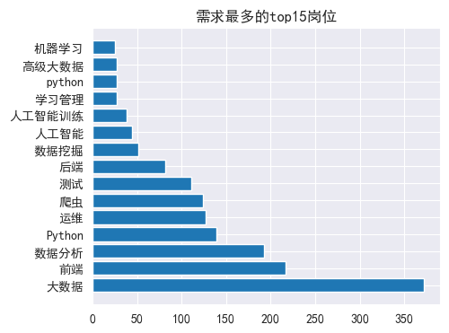

```python
#可视化
plt.figure(figsize=(5,4))
plt.title('需求最多的top15岗位')
plt.barh(job[0:15].index, job[0:15].values)
plt.show()
```

- 通过统计的结果可以知道，有关数据方面的岗位需求较多，最多的招聘岗位为大数据，前端岗位方向的招聘为第二。
- 企业需要大量的数据方向人才。

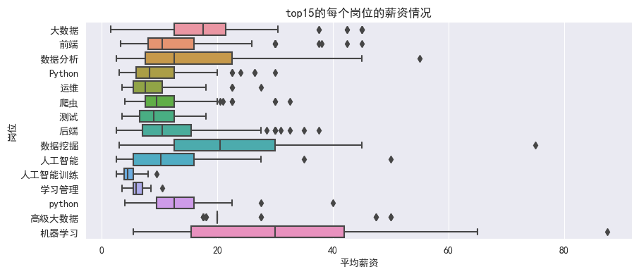

```python
#top15的每个岗位的薪资情况
plt.figure(figsize=(10,4))
plt.title('top15的每个岗位的薪资情况')
top_g = data[data['岗位'].apply(lambda x: x  in job[0:15].index )]  #top15的岗位
sns.boxplot(top_g, y='岗位',x='平均薪资', order=job[0:15].index)
# plt.xticks(rotation=30)
plt.show()
```

- 从岗位的薪资来看，有关数据方面的岗位的数量较大并且平均薪资较高

## 地区统计及分析

```python
#根据地区进行分组统计招聘数量
city = data['地区2'].value_counts()
city
```

```
北京             445
上海             290
深圳             222
杭州             191
南京             145
              ...
聊城               1
宿迁               1
江门               1
鹤壁               1
克孜勒苏柯尔克孜自治州      1
Name: 地区2, Length: 177, dtype: int64
```

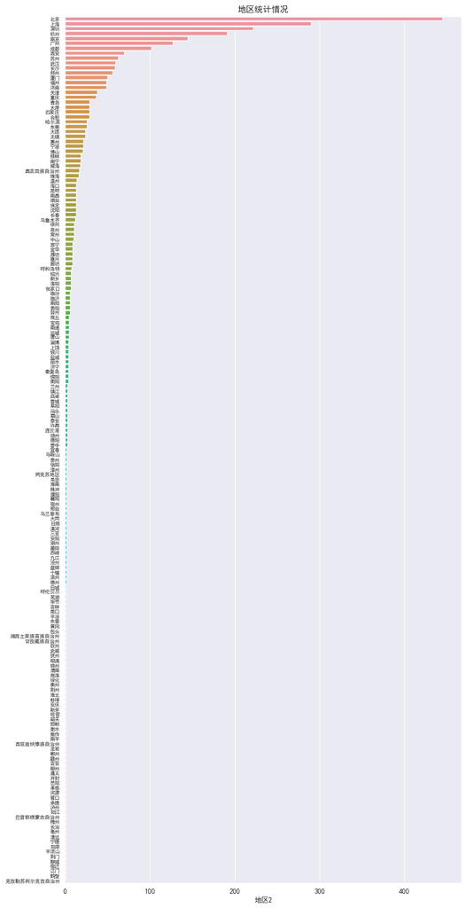

```python
plt.figure(figsize=(10,22))
plt.title('地区统计情况')
sns.barplot( y=city.index, x=city, orient='h')
plt.yticks(fontsize=7)
plt.show()
```

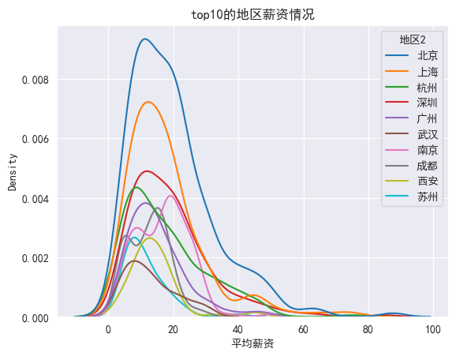

```python
#统计top10的地区薪资情况，薪资用每个岗位的平均薪资
plt.title('top10的地区薪资情况')
top_city = data[data['地区2'].apply(lambda x: x in city[0:10].index)]

sns.kdeplot(top_city, x='平均薪资',hue='地区2')
plt.show()
```

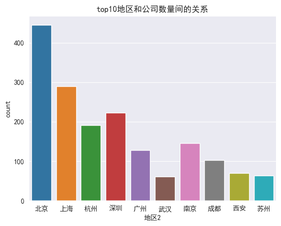

```python
#top10地区和公司数量间的关系
plt.title('top10地区和公司数量间的关系')
sns.countplot(top_city, x='地区2')
plt.show()
```

- 大量的招聘来自大型的城市。因为这些大城市的经济较为发达，提供的就业机会较多。
- 前10的城市的岗位薪资普遍在8K到25k之间，北京的招聘岗位较多并且薪资较高

## 公司统计及分析

```python
#统计公司的数量
com = data['公司名'].value_counts()
com.head(10)
```

```
中软国际          151
法本             67
博彦科技           53
软通动力信息技术集团     37
神州信息           18
中电金信           17
腾讯             16
软通动力           15
今日头条           14
华为             14
Name: 公司名, dtype: int64
```

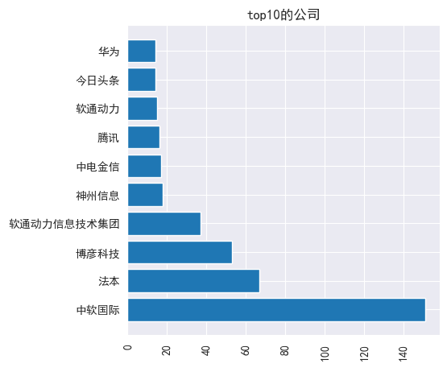

```python
#top10的公司
plt.figure(figsize=(5,5))
plt.title('top10的公司')
plt.barh(com.head(10).index, com.head(10).values,)
plt.xticks(rotation=90)
plt.show()
```

```python
#统计所有公司的规模
t = data[['公司名','规模']].drop_duplicates('公司名') #去重
gm = t['规模'].value_counts()
gm
```

```
59       550
299      461
5499     311
10       296
10000    176
749      140
Name: 规模, dtype: int64
```

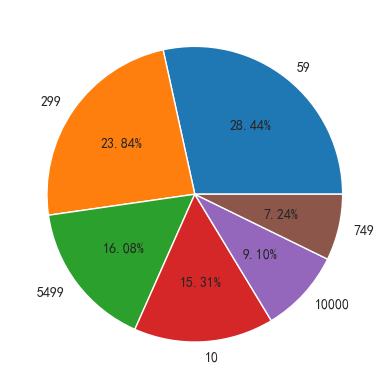

```python
plt.pie(gm, labels=gm.index, autopct='%.2f%%')
plt.show()
```

- 招聘人数最多的公司为中软国际，共有1934家公司，大部分的公司招聘岗位较少。
- 大部分公司的规模在500人以下的规模。

## 公司的领域

```python
#统计前10的领域
ly = data['公司领域'].value_counts()
ly
```

```
计算机软件          893
互联网            498
移动互联网          186
数据服务           154
电子商务           120
              ...
租赁/拍卖/典当/担保      1
音乐/视频/阅读         1
装修装饰             1
地产经纪/中介          1
婚庆/摄影            1
Name: 公司领域, Length: 82, dtype: int64
```

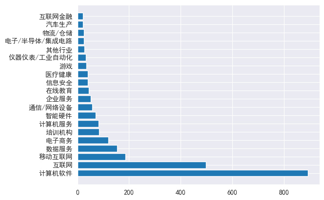

```python
plt.barh(ly.head(20).index,ly.head(20).values,)
plt.show()
```

- 通过统计可以发现，最多的岗位为IT行业相关的岗位。说明IT行业对于人的需求量大。

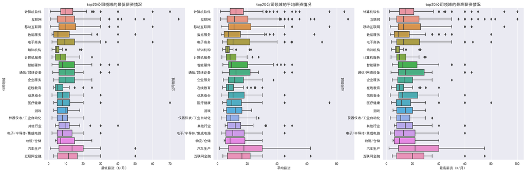

```python
#公司领域和薪资间的关系,前20的公司领域
top_ly = data[data['公司领域'].apply(lambda x : x in ly.head(20).index)]
plt.figure(figsize=(25,8))


plt.subplot(1,3,1)
plt.title('top20公司领域的最低薪资情况')
sns.boxplot(top_ly, x='最低薪资（K/月）', y='公司领域',order=ly.head(20).index)

plt.subplot(1,3,2)
plt.title('top20公司领域的平均薪资情况')
sns.boxplot(top_ly, x='平均薪资', y='公司领域',order=ly.head(20).index)

plt.subplot(1,3,3)
plt.title('top20公司领域的最高薪资情况')
sns.boxplot(top_ly, x='最高薪资（K/月）', y='公司领域',order=ly.head(20).index)
plt.show()
```

## 福利的词云图

```python
import pyecharts.options as opts
from pyecharts.charts import WordCloud
from pyecharts.globals import SymbolType

word = data['福利'].values.tolist() #'福利'列的值
word_count = {}  #存放词频
for i in word:   #统计词频
    t=i.split('，') #
    for j in t:
        try:
            word_count[j] += 1
        except:
            word_count[j]=1

#生成词云图
c = (
    WordCloud()
    .add("", word_count.items(), word_size_range=[20, 100], shape=SymbolType.DIAMOND)
    .set_global_opts(title_opts=opts.TitleOpts(title="公司福利词云图"))
)
c.render_notebook()
```

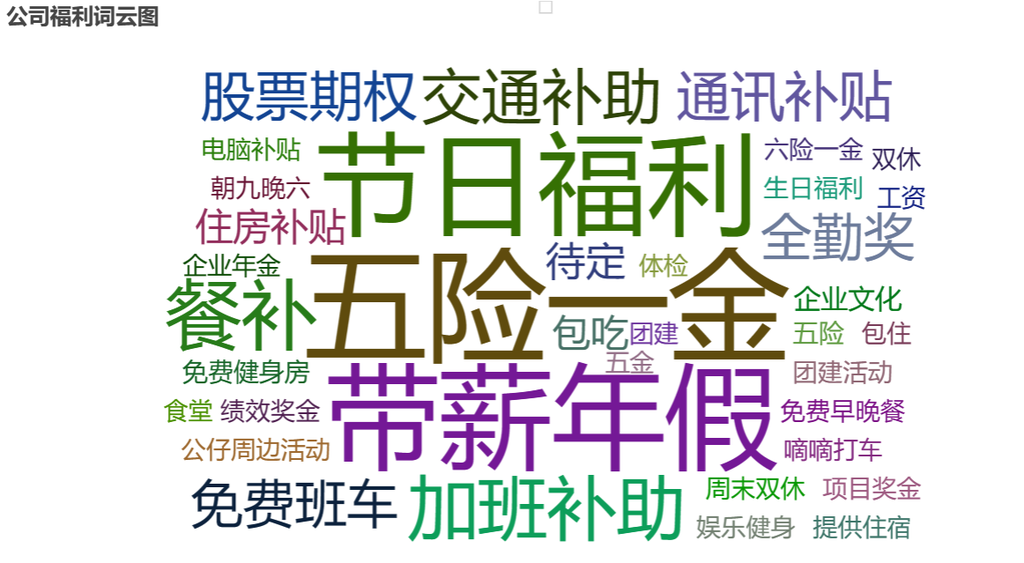

- 从词频图中可以看到，节日福利、五险一金和带薪年假是在招聘中的公司福利出现的次数最多。而这三个福利也是工作者的关注部分。